# Lab 6 - Convolutional Network Architectures

### Matan Segal

Data set was tooken from:

https://www.kaggle.com/paultimothymooney/chest-xray-pneumonia#person1951_bacteria_4882.jpeg

In this lab I will use a data set of pictures of chest x ray images from people with pneumonia and people without. In order to eveluate the algorithm’s performance I will use the confusion matrix of my algorithm output and the real values. Since we are handling with medical diagnosis, the case of false negative (where we diagnosis a person is healthy where he is actually not) is worse than false positive because it is better to be on the safe side rather than missing a person with pneumonia. Therefore, I will use the following weight metrix for evaluation:

|  | pred 0 | pred 1 |
| --- | --- | --- |
| real 0 | 0 | 1 |
| real 1 | 3 | 0 |

when I will have the output of the model I will multiply the confusion matrix with the weight matrix and sum all the element of the product mertix. The lower the sum will be, the better the model is.

```python
import glob
import matplotlib.pyplot as plt
import matplotlib.image as mpimg
import numpy as np

normal_data_train = glob.glob('chest_xray/train/NORMAL/*.jpeg')
normal_data_test = glob.glob('chest_xray/test/NORMAL/*.jpeg')
pneumonia_data_train = glob.glob('chest_xray/train/PNEUMONIA/*.jpeg')
pneumonia_data_test = glob.glob('chest_xray/test/PNEUMONIA/*.jpeg')
```

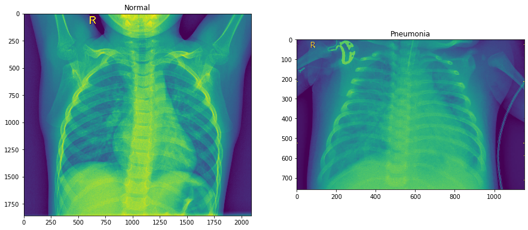

```python
toShowList = [normal_data_train[0],pneumonia_data_train[0]]
titles = ['Normal','Pneumonia']

plt.figure(figsize=(15,20))

for i,item in enumerate(toShowList):
    plt.subplot(1, 2, i + 1)
    img = mpimg.imread(item)
    imgplot = plt.imshow(img)
    plt.title(titles[i], size=12)

plt.show()
```

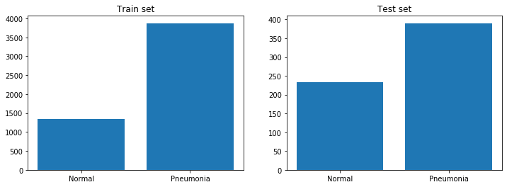

```python
fig = plt.figure(figsize=(12,4))
plt.subplot(1, 2, 1)
plt.bar(titles, [len(normal_data_train),len(pneumonia_data_train)])
plt.title('Train set')
plt.subplot(1, 2, 2)
plt.bar(titles, [len(normal_data_test),len(pneumonia_data_test)])
plt.title('Test set')
```

As we can see the train set and the test one are unbalanced, therefore I added more normal chest x-ray images from:

https://www.kaggle.com/neilturley/nihcc-chest-xray#00000001_001.png

The dataset above contains many chest x-ray images, so I filter just the normal ones (labeled as "No Finding"). Adding 2500 normal chest x-ray images, I will combine the train and the test set and later split it.

```python
normal_data_train2 = glob.glob('chest_xray/new_normal/*.png')
normal_data_train3 = normal_data_train + normal_data_train2
print(len(normal_data_train3))
```

[output not shown]

First, I will resize all the images to a size of 100x100 pixels. Few of the images were in a rbg scale, so I conver those into a gray scale.

```python
from PIL import Image
from resizeimage import resizeimage

# a function to return grey in case of rgb
def rgb2gray(rgb):
    r, g, b = rgb[:,:,0], rgb[:,:,1], rgb[:,:,2]
    gray = 0.2989 * r + 0.5870 * g + 0.1140 * b
    return gray


def resize(img, asnumpy = True):
    with open(img, 'r+b') as f:
        with Image.open(f) as image:
            cover = resizeimage.resize_cover(image, [100, 100], validate=False)
            ret_val = np.array(cover)
            if len(ret_val.shape) == 3:     # if rgb convert to grey
                ret_val = rgb2gray(ret_val)
            return ret_val if asnumpy else cover
```

```python
# representation of the images when I will process them

resize(normal_data_train[0],False)
```

```python
normal_resize_train = []
pneumonia_resize_train = []
normal_resize_test = []
pneumonia_resize_test = []

for i in normal_data_train3:
    normal_resize_train.append(resize(i))

for i in pneumonia_data_train:
    pneumonia_resize_train.append(resize(i))

for i in normal_data_test:
    normal_resize_test.append(resize(i))

for i in pneumonia_data_test:
    pneumonia_resize_test.append(resize(i))
```

```python
# combining all into one set:

img_wh = 100
X0 = normal_resize_train + normal_resize_test
X1 = pneumonia_resize_train + pneumonia_resize_test
y0 = np.zeros(len(X0))
y1 = np.ones(len(X1))
y = np.hstack((y0,y1))
X = X0 + X1
X = np.array(X).reshape((len(X),img_wh,img_wh,1))

print(X.shape,y.shape)
```

```
(8340, 100, 100, 1) (8340,)
```

### Dividing the data

Now that we have pretty big data set (8340 images) which is quit balanced, I am confidence saying that after shuffling the data and randomly split it into 80% training set and 20% testing set, the performance of the model on the testing set will be very similar to the actual performance of the model on average on any data set.

```python
from sklearn.model_selection import train_test_split

# spliting to train and test
X_train, X_test, y_train, y_test = train_test_split(X, y,
                                test_size=0.20, random_state=42, stratify=y)
```

```python
print('X_train shape:',X_train.shape)
print('X_test shape:',X_test.shape)
print('y_train shape:',y_train.shape)
print('y_test shape:',y_test.shape)
```

```
X_train shape: (6672, 100, 100, 1)
X_test shape: (1668, 100, 100, 1)
y_train shape: (6672,)
y_test shape: (1668,)
```

```python
# shuffle the data and normalize it

import random

def shuffle_two(a,b):
    c = list(zip(a,b))
    random.shuffle(c)
    a , b = zip(*c)
    return np.array(a), np.array(b)

X_test, y_test = shuffle_two(X_test, y_test)
X_train, y_train = shuffle_two(X_train, y_train)

# normalize the data [0,1]
X_test = X_test/255
X_train = X_train/255
```

Summary function for visualization:

```python
from sklearn import metrics as mt
import seaborn as sns
import pandas as pd
%matplotlib inline

def summarize_net(net, X_test, y_test, title_text=''):
    yhat = net.predict(X_test).round()
    acc = mt.accuracy_score(y_test,yhat)
    cm = mt.confusion_matrix(y_test,yhat)
    eval_weights = np.array([[0,1],[3,0]])
    eval_val = np.sum(cm * eval_weights)
    cm = cm/np.sum(cm,axis=1)[:,np.newaxis]
    print('Evaluation value according to the metrix shown at the beginning:',eval_val)
    cm = pd.DataFrame(cm , index = ['0','1'] , columns = ['0','1'])
    plt.figure(figsize = (6,6))
    sns.heatmap(cm,cmap= "coolwarm", linecolor = 'black' ,
                linewidth = 1 , annot = True, fmt='.2f')
    plt.title(title_text+'{:.4f}'.format(acc))
```

```python
import keras
from keras.models import Sequential
from keras.layers import Reshape
from keras.layers import Dense, Dropout, Activation, Flatten
from keras.layers import Conv2D, MaxPooling2D
from keras.preprocessing.image import ImageDataGenerator
from keras.callbacks import EarlyStopping
from keras.regularizers import l2
from keras.layers import average
from keras.models import Input, Model

keras.__version__
```

```
'2.3.1'
```

```python
# adding gerenalization to the set:

datagen = ImageDataGenerator(
    rotation_range=10,
    width_shift_range=0.05,
    height_shift_range=0.05,
    shear_range=0.,
    zoom_range = 0.15,
    channel_shift_range=0.,
    fill_mode='nearest',
    cval=0.,
    horizontal_flip=False,
    vertical_flip=False,
    rescale=None)

datagen.fit(X_train)
tmps = datagen.flow(X_train, y_train, batch_size=1)
```

## Model 1 - Regular CNN

```python
l2_lambda = 0.0001

cnn = Sequential()

cnn.add(Conv2D(filters=32,
               input_shape = (img_wh,img_wh,1),
               kernel_size=(3,3),
               kernel_initializer='he_uniform',
               kernel_regularizer=l2(l2_lambda),
               padding='same',
               activation='relu',
               data_format="channels_last"))

cnn.add(MaxPooling2D(pool_size=(2, 2), data_format="channels_last"))

cnn.add(Conv2D(filters=64,
               kernel_size=(3,3),
               kernel_initializer='he_uniform',
               kernel_regularizer=l2(l2_lambda),
               padding='same',
               activation='relu',data_format="channels_last"))

cnn.add(MaxPooling2D(pool_size=(2, 2), data_format="channels_last"))

cnn.add(Conv2D(filters=128,
               input_shape = (img_wh,img_wh,1),
               kernel_size=(3,3),
               kernel_initializer='he_uniform',
               kernel_regularizer=l2(l2_lambda),
               padding='same',
               activation='relu',
               data_format="channels_last"))

cnn.add(Conv2D(filters=128,
               kernel_size=(3,3),
               kernel_initializer='he_uniform',
               kernel_regularizer=l2(l2_lambda),
               padding='same',
               activation='relu',data_format="channels_last"))

cnn.add(MaxPooling2D(pool_size=(2, 2), data_format="channels_last"))


cnn.add(Flatten())
cnn.add(Dropout(0.5)) # to prevent over fitting
cnn.add(Dense(128,activation='relu'))
cnn.add(Dropout(0.5))
cnn.add(Dense(1,activation='sigmoid'))

# training the model
cnn.compile(loss='binary_crossentropy',
              optimizer='adam',
              metrics=['accuracy'])
```

```python
cnn.fit(datagen.flow(X_train,y_train, batch_size = 128) ,
                      epochs=10, verbose=1,
                      validation_data=(X_test,y_test),
                      callbacks=[EarlyStopping(monitor='val_loss', patience=4)],
                     )
```

```
<keras.callbacks.callbacks.History at 0x2a6f511a3c8>
```

```
Evaluation value according to the metrix shown at the beginning: 264
```

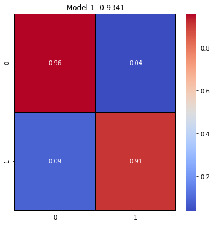

```python
summarize_net(cnn, X_test, y_test, title_text='Model 1: ')
```

## Model 2: Adding ResNet

In this model, I will take model 1 and add more layers to it. In addition, I will add two split layes, one after the second layer and one after all the layers from the first model.

```python
from keras.layers import Add

input_holder = Input(shape=(img_wh, img_wh, 1))

resnet = Conv2D(filters=32,
               input_shape = (img_wh,img_wh,1),
               kernel_size=(3,3),
               kernel_initializer='he_uniform',
               kernel_regularizer=l2(l2_lambda),
               padding='same',
               activation='relu',
               data_format="channels_last")(input_holder)

resnet = MaxPooling2D(pool_size=(2, 2), data_format="channels_last")(resnet)

resnet = Conv2D(filters=64,
               kernel_size=(3,3),
               kernel_initializer='he_uniform',
               kernel_regularizer=l2(l2_lambda),
               padding='same',
               activation='relu',data_format="channels_last")(resnet)

split1 = MaxPooling2D(pool_size=(2, 2), data_format="channels_last")(resnet)

resnet = Conv2D(filters=128,
               kernel_size=(3,3),
               kernel_initializer='he_uniform',
               kernel_regularizer=l2(l2_lambda),
               padding='same',
               activation='relu',
               data_format="channels_last")(split1)

resnet = Conv2D(filters=64,
               kernel_size=(3,3),
               kernel_initializer='he_uniform',
               kernel_regularizer=l2(l2_lambda),
               padding='same',
               activation='relu',data_format="channels_last")(resnet)

resnet = Add()([resnet, split1])    # connecting the first split
resnet = Activation("relu")(resnet)

split2 = MaxPooling2D(pool_size=(2, 2), data_format="channels_last")(resnet)

resnet = Conv2D(filters=256,
               kernel_size=(3,3),
               kernel_initializer='he_uniform',
               kernel_regularizer=l2(l2_lambda),
               padding='same',
               activation='relu',data_format="channels_last")(split2)


resnet = Conv2D(filters=64,
               kernel_size=(3,3),
               kernel_initializer='he_uniform',
               kernel_regularizer=l2(l2_lambda),
               padding='same',
               activation='relu',
               data_format="channels_last")(resnet)

resnet = Add()([resnet, split2])    # connecting the second split
resnet = Activation("relu")(resnet)

resnet = MaxPooling2D(pool_size=(2, 2), data_format="channels_last")(resnet)

resnet = Flatten()(resnet)
resnet = Dropout(0.25) (resnet)
resnet = Dense(256,activation='relu')(resnet)
resnet = Dropout(0.5) (resnet)
resnet = Dense(1,activation='sigmoid')(resnet)

Resnet = Model(inputs=input_holder,outputs=resnet)

# training the model
Resnet.compile(loss='binary_crossentropy', # mean_squared_error - doesn't work!
              optimizer='adam',
              metrics=['accuracy'])
```

```python
Resnet.fit(X_train, y_train, batch_size=128,
                      epochs=10, verbose=1,
                      validation_data=(X_test,y_test),
                      callbacks=[EarlyStopping(monitor='val_loss', patience=4)],
                     )
```

```
Train on 6672 samples, validate on 1668 samples
```

```
<keras.callbacks.callbacks.History at 0x2a715d970c8>
```

```
Evaluation value according to the metrix shown at the beginning: 120
```

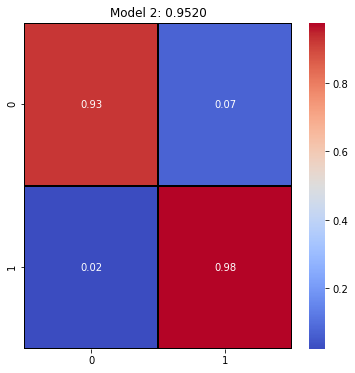

```python
summarize_net(Resnet, X_test, y_test, title_text='Model 2: ')
```

### Comparison

Like I declared at the beginning, the lower the evaluation value, the better the model is. We can clearly see that the performance of model 2 – the ResNet model (evaluation value of 120) , is much better than the performance of the regular convolutional network in model one (eval vlue of 264). Also, from the representations of the confusion metrices, we can see that most of the incorrect predictions of the false negative that occurred in model 1, which are the more expensive mistakes, reduced to 2%. If we also compare the accuracy of the two, we see that model 2 got about 2% higher accuracy than model 1.

### MLP Model:

```python
# resizing the training and the testin set into 2D:

X_train_MLP = np.reshape(X_train,(X_train.shape[0],img_wh**2))
X_test_MLP = np.reshape(X_test,(X_test.shape[0],img_wh**2))

inputs = Input(shape=(X_train_MLP.shape[1],))

x = Dense(units=256, activation='relu')(inputs)
x = Dense(units=256, activation='relu')(x)
x = Dense(units=128, activation='relu')(x)
x = Dense(units=128, activation='relu')(x)
x = Dense(units=64, activation='relu')(x)
x = Dense(units=32, activation='relu')(x)
x = Dense(units=16, activation='relu')(x)
predictions = Dense(1,activation='sigmoid')(x)

MLP_model = Model(inputs=inputs, outputs=predictions)


MLP_model.compile(optimizer='adam',
              loss='binary_crossentropy',
              metrics=['accuracy'])
```

```python
history_MLP = MLP_model.fit(X_train_MLP, y_train, batch_size=128,
                      epochs=10, verbose=1,
                      validation_data=(X_test_MLP,y_test),
                      callbacks=[EarlyStopping(monitor='val_loss', patience=4)],
                     )
```

```
Train on 6672 samples, validate on 1668 samples
```

```
Evaluation value according to the metrix shown at the beginning: 185
```

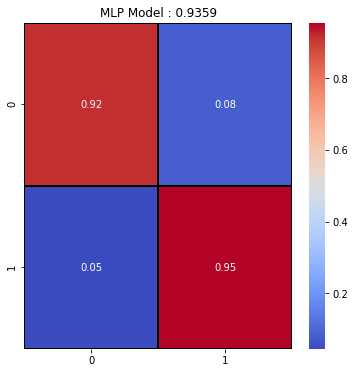

```python
summarize_net(MLP_model, X_test_MLP, y_test, title_text='MLP Model : ')
```